# Identify Fraud From Enron Email

## Understanding the Dataset and Question

The purpose of this project is to use the tools learned in the machine learning Udacity course to identify Enron employees (Persons of Interest -POI) who have committed fraud based on the public Enron financial and email dataset regarding the widespread corporate fraud case in 2002. POIs are defined as one of three: indicted, settled without admitting guilt, or testified in exchange of immunity.

## Question 1

> Summarize for us the goal of this project and how machine learning is useful in trying to accomplish it. As part of your answer, give some background on the dataset and how it can be used to answer the project question. Were there any outliers in the data when you got it, and how did you handle those? [relevant rubric items: “data exploration”, “outlier investigation”]

### Data Exploration

The dataset contains approximately 146 users, 18 users are considered POIs, while the remaining 128 users are non-POIs, the emails are mostly real that were exchanged by Enron senior management. Machine learning on this dataset will help to answer questions such as "can we identify patterns in the emails?" With regression we can understand the relationship between an individual's salary and their bonuses for example. By clustering we can identify who was on the board of directors, and who is just an employee.

The dataset contains 21 features that can be either financial, email, or related to POI/non-POI.

- **financial_features** = ['salary', 'deferral_payments', 'total_payments', 'loan_advances', 'bonus', 'restricted_stock_deferred', 'deferred_income', 'total_stock_value','expenses', 'exercised_stock_options', 'other', 'long_term_incentive', 'restricted_stock', 'director_fees']
- **email_features** = ['to_messages', 'email_address', 'from_poi_to_this_person', 'from_messages', 'from_this_person_to_poi', 'shared_receipt_with_poi']
- **POI_label** = ['poi'] This is a boolean which is represented as an integer.

Some features have a decent amount of missing values or "NaNs". Listed below displays each feature and how many values it's missing:

**salary:** 51, **to_messages:** 60, **deferral_payments:** 107, **total_payments:** 21, **loan_advances:** 142, **bonus:** 64, **email_address:** 35, **restricted_stock_deferred:** 128, **total_stock_value:** 20, **shared_receipt_with_poi:** 60, **long_term_incentive:** 80, **exercised_stock_options:** 44, **from_messages:** 60, **other:** 53, **from_poi_to_this_person:** 60, **from_this_person_to_poi:** 60, **poi:** 0, **deferred_income:** 97, **expenses:** 51, **restricted_stock:** 36, **director_fees:** 129

An easy way to fix this is to replace "NaNs" with a 0.

### Outlier Investigation

As I plotted bonus vs. salary, there are a few outlier datapoints. They actually represented the 'TOTAL', 'FREVERT MARK A', 'THE TRAVEL AGENCY IN THE PARK' columns. I went ahead and removed the outliers.

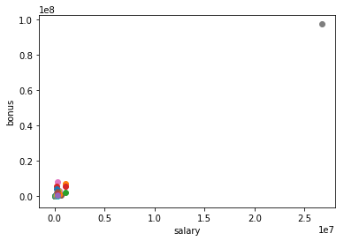

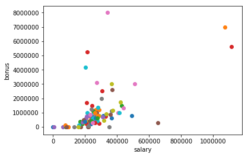

The scatterplot spread is much clearer now after removing the outlier.

## Question 2

> What features did you end up using in your POI identifier, and what selection process did you use to pick them? Did you have to do any scaling? Why or why not? As part of the assignment, you should attempt to engineer your own feature that does not come ready-made in the dataset -- explain what feature you tried to make, and the rationale behind it. (You do not necessarily have to use it in the final analysis, only engineer and test it.) In your feature selection step, if you used an algorithm like a decision tree, please also give the feature importances of the features that you use, and if you used an automated feature selection function like SelectKBest, please report the feature scores and reasons for your choice of parameter values. [relevant rubric items: “create new features”, “intelligently select features”, “properly scale features”]

I have went ahead and added two additional features which are: **fraction_from_poi** and **fraction_to_poi**. The **fraction_from_poi** calculates the ratio of the messages from a POI to this person against all the messages sent to this specific individual. The **fraction_to_poi** does the opposite and calculates thr ratio from this person to a POI against all messages from that specific individual.

This **computeFraction** code listed below shows how the ratios are calculated with messages to/from that person that are from/to a POI, given a number of messages to/from POI (numerator) and number of all messages to/from a person (denominator).

```python
def computeFraction(poi_messages, all_messages):

    fraction = 0
    if poi_messages != 'NaN' and all_messages != 'NaN':
        fraction = poi_messages/float(all_messages)
```

### Univariate Feature Selection

To figure out the best features to use, I decided to use an automated feature selection function, SelectKBest, which decides the K features that are most powerful (where K is a parameter). The output listed below is the **SelectKBest** scores for all the features, from highest to lowest. I decided to use the first 10 features (k = 10) including POI since they had the highest scores from SelectKBest results. The reason I chose to use 10 features is because 10 is the default value and will give us an accurate representation.

| Features | Score |
| --- | --- |
| Exercised_stock_options | 26.02987911225831 |
| Total_stock_value | 25.54922089067772 |
| Salary | 23.381102434442752 |
| Bonus | 21.24742713069242 |
| Fraction_to_poi | 16.71451391010863 |
| Deferred_income | 16.075108449652593 |
| Long_term_incentive | 10.553413095745798 |
| Restricted_stock | 9.704890359316096 |
| Shared_receipt_with_poi | 9.280727849609136 |
| Total_payments | 9.269839351304077 |
| Loan_advances | 7.180961848232588 |
| Other | 7.127384704342793 |
| Expenses | 6.307418356314026 |
| From_poi_to_this_person | 5.965369505823437 |
| Fraction_from_poi | 3.320446045681815 |
| From_this_person_to_poi | 2.345616720239484 |
| Director_fees | 2.1453342495720547 |
| To_messages | 1.7220492206241136 |
| From_messages | 0.17499018320838547 |
| Deferral_payments | 0.08579272662370419 |
| Restricted_stock_deferred | 0.06602324536688738 |

To observe the impact of adding the two new features, I looked at the performance of multiple algorithms with the original features, and compared it to the performance which includes the new features.

| Algorithm | Precision | Recall | Precision | Recall |
| --- | --- | --- | --- | --- |
| NA | Excludes New Features | Excludes New Features | Includes New Features | Includes New Features |
| Naive Bayes | 0.402857871295 | 0.369751984127 | 0.38384036919 | 0.374543650794 |
| SVM | 0.266666666667 | 0.0790376984127 | 0.210902777778 | 0.076443452381 |
| Decison Tree | 0.298849206349 | 0.29626984127 | 0.335379689755 | 0.340486111111 |
| Random Forest | 0.426979166667 | 0.198363095238 | 0.521666666667 | 0.208953373016 |
| Logistic Regression | 0.0 | 0.0 | 0.0 | 0.0 |

Based on the table it is evident that performance varies amongst the different algorithms. Some algorithms have a better performance with the inclusion of the new features,these are the Decision Tree and Random Forest. Other algorithms perform worse when the new features are included, such as Naive Bayes and SVM.

I decided to use the first 10 features (k = 10) including POI since they had the highest scores from SelectKBest results. The reason I chose to use 10 features is because 10 is the default value and will give us an accurate representation. Even though one of my new features recevied a high score, I decided against including it in the final features list as the best model performance from Naive Bayes was obtained without it.

The 10 features being used including POI are: exercised_stock_options, total_stock_value, salary, bonus, deferred_income, long_term_incentive, restricted_stock, shared_receipt_with_poi, total_payments, and loan_advances.

### Feature Scaling

As the 10 features have different units of measurement and some contain large values, I must transform them. I used MinMaxScaler from sklearn to scale all my selected features to a given range 0 - 1. Below is the function and code used.

```python
from sklearn import preprocessing

data = featureFormat(my_dataset, kBest_features, sort_keys = True)
labels, features = targetFeatureSplit(data)
scaler = preprocessing.MinMaxScaler()
features = scaler.fit_transform(features)
```

## Question 3

> What algorithm did you end up using? What other one(s) did you try? How did model performance differ between algorithms? [relevant rubric item: “pick an algorithm”]

### Pick an Algorithm

I used 5 different algorithms which are listed below:

- Naive Bayes (algorithm that is ultimately being used)
- SVM
- Decision Tree
- Random Forest
- Logistic Regression

Some algorithms took longer such as SVM and Logistic Regression models. All the algorithms had a high accuracy around 0.80 , which indicates that accuracy in this case is not the best evaluation metric because a shortcoming is that it's not ideal for skewed classes.

## Question 4

> What does it mean to tune the parameters of an algorithm, and what can happen if you don’t do this well? How did you tune the parameters of your particular algorithm? (Some algorithms do not have parameters that you need to tune -- if this is the case for the one you picked, identify and briefly explain how you would have done it for the model that was not your final choice or a different model that does utilize parameter tuning, e.g. a decision tree classifier). [relevant rubric item: “tune the algorithm”]

Most classifiers come with a set of parameters along with default values which can impact the model, and they are passed as arguments to the constructor. Some examples are criterion and splitter used for Decision Tree Classifiers. Tuning the parameters of a classifier allows the optimization of the values of those parameters to enable the algorithm to perform at its best. It is usually the last step of the applied machine learning process before presenting results. If this is poorly done, it most often can lead to the model incorrectly fitting the data.

### Tune the Algorithm

GridSearchCV from sklearn was used for parameter tuning in the three algorithms that had parameters: SVM, Decision Tree, and Logistic Regression. Grid search will systematically build and evaluate a model for each combination of algorithm parameters specified in the grid.

The function below helped to tune the algorithm using grid search. It prints out the best hyperparameters for the model after performing the tuning for a specified number of iterations, along with the average evaluation metrics results: accuracy, precision, and recall.

```python
def tune_params(grid_search, features, labels, params, iters = 80):

    acc = []
    pre = []
    recall = []
    for i in range(iters):
        features_train, features_test, labels_train, labels_test = \
        train_test_split(features, labels, test_size = 0.3, random_state = i)
        grid_search.fit(features_train, labels_train)
        predicts = grid_search.predict(features_test)

        acc = acc + [accuracy_score(labels_test, predicts)]
        pre = pre + [precision_score(labels_test, predicts)]
        recall = recall + [recall_score(labels_test, predicts)]
    print "accuracy: {}".format(np.mean(acc))
    print "precision: {}".format(np.mean(pre))
    print "recall: {}".format(np.mean(recall))

    best_params = grid_search.best_estimator_.get_params()
    for param_name in params.keys():
        print("%s = %r, " % (param_name, best_params[param_name]))
```

#### Tuning the Three Algorithms with Parameters

```python
## Tuning SVM

from sklearn import svm
svm_clf = svm.SVC()
svm_param = {'kernel':('linear', 'rbf', 'sigmoid'),
'gamma': [1, 0.1, 0.01, 0.001, 0.0001],
'C': [0.1, 1, 10, 100, 1000]}
svm_grid_search = GridSearchCV(estimator = svm_clf, param_grid = svm_param)
```

**Results:** kernel = 'linear', C = 0.1, gamma = 1

```python
## Decision Tree

from sklearn import tree
dt_clf = tree.DecisionTreeClassifier()
dt_param = {'criterion':('gini', 'entropy'),
'splitter':('best','random')}
dt_grid_search = GridSearchCV(estimator = dt_clf, param_grid = dt_param)
```

**Excluding New Feature Results:** splitter = 'random', criterion = 'entropy'

**Including New Feature Results:** splitter = 'random', criterion = 'gini'

```python
## Logistic Regression

from sklearn.linear_model import LogisticRegression
lr_clf = LogisticRegression()
lr_param = {'tol': [1, 0.1, 0.01, 0.001, 0.0001],
'C': [0.1, 0.01, 0.001, 0.0001]}
lr_grid_search = GridSearchCV(estimator = lr_clf, param_grid = lr_param)
```

**Results:** C = 0.1, tol = 1

## Question 5

> What is validation, and what’s a classic mistake you can make if you do it wrong? How did you validate your analysis? [relevant rubric item: “validation strategy”]

Validation is a process in which a trained model is evaluated with a testing dataset. It is very important to split your data to training/testing datasets, if not it leads to overfitting. I used the **Cross Validation train_test_split** function to split 30% of the dataset for testing. The random_state I selected as 43 because that is 30% of the entire dataset. After that I used **sklearn.metrics** accuracy, precision and recall scores to validate my algorithms.

```python
from sklearn.cross_validation import train_test_split
from sklearn import cross_validation
features_train, features_test, labels_train, labels_test = \
     cross_validation.train_test_split(features, labels, test_size=0.3, random_state=43)

from sklearn.metrics import accuracy_score, precision_score, recall_score
```

| Algorithm | Accuracy | Precision | Recall |
| --- | --- | --- | --- |
| Naive Bayes | 0.813953488372093 | 0.3333333333333333 | 0.6 |
| SVM | 0.8837209302325582 | 0.0 | 0.0 |
| Decision Tree | 0.8604651162790697 | 0.3333333333333333 | 0.2 |
| Random Forest | 0.8837209302325582 | 0.5 | 0.2 |
| Logistic Regression | 0.9069767441860465 | 1.0 | 0.2 |

## Question 6

> Give at least 2 evaluation metrics and your average performance for each of them. Explain an interpretation of your metrics that says something human-understandable about your algorithm’s performance. [relevant rubric item: “usage of evaluation metrics”]

### Evaluation Metrics

Precision is calculated as the True Positive / (True Positive + False Positive). This simply means out of all items labeled as postive, how many are truly positive.

Recall is calcualted as the True Positive / (True Positive + False Negative). WHich means out of all the items that are truly positive, how many were correctly classified as positive.

The chosen algorithm is Naive Bayes, which has an accuracy of 0.83100, precision of 0.39507, and recall of 0.34450.

GaussianNB(priors=None) Accuracy: 0.83100 Precision: 0.39507 Recall: 0.34450 F1: 0.36806 F2: 0.35355 Total predictions: 14000 True positives: 689 False positives: 1055 False negatives: 1311 True negatives: 10945

#### References

- I utilized https://stackoverflow.com when I came across errors in my coding.
- I also utilized https://scikit-learn.org/stable/ to learn about what sklearn has.